# Biostatistics - Bioinformatics for Computational Genomics

Final Examination Template

Chiara Simiele

Academic Year 2025/2026

# Student Information

| Field | Information |
| --- | --- |
| **Name** | Chiara |
| **Surname** | Simiele |
| **Student ID** | 69894A |
| **Personal Code** | 10769665 |

# Instructions

- Answer **only the two assigned questions**
- Clearly justify all methodological choices
- Report relevant statistical results
- Provide biological and clinical interpretation of findings
- Include comments directly below each code chunk

# Initial Setup

## 1. Load Required Libraries

```r
library(survival)
library(survminer)
library(dplyr)
library(stats)
```

## 2. Load the Dataset

```r
endometriosis_copy <- read.csv("endometriosis_copy.csv")
endometriosis_gene <- read.csv("endometriosis_gene.csv")
endometriosis_meth <- read.csv("endometriosis_meth.csv")
```

## 3. Preliminary Data Inspection

```r
str(endometriosis_copy)    #312 rows e 24794 columns
```

```
## 'data.frame':    312 obs. of  24794 variables:
##  $ patient_id                     : int  1 2 3 4 5 6 7 8 9 10 ...
##  $ diagnosis_group                : chr  "Endometriosis" "Atypical endometriosis" "Endometriosis" "Atypical endometriosis" ...
##  $ age                            : int  43 45 46 45 71 30 28 74 35 40 ...
##  $ menopausal_status              : chr  "Premenopausal" "Premenopausal" "Premenopausal" "Premenopausal" ...
##  $ ethnicity                      : chr  "White" "Asian" "Asian" "White" ...
##  $ BMI                            : num  22.3 22.1 24.1 30.5 29.2 23.6 18.3 21.6 23.2 25.4 ...
##  $ lesion_type                    : chr  "Deep infiltrating endometriosis" "Ovarian endometrioma" "Superficial endometriosis" "Ovarian endometrioma" ...
##  $ endometrioma_size              : num  4.5 6.6 5.2 6.7 0.6 3.4 4.1 5.2 1.7 5.6 ...
##  $ bilateral_disease              : int  0 0 0 0 1 1 0 0 0 1 ...
##  $ family_history                 : int  0 0 0 0 0 0 1 0 1 0 ...
##  $ histological_type              : chr  "Not applicable" "Not applicable" "Not applicable" "Not applicable" ...
##  $ disease_stage                  : chr  "Stage I" "Stage II" "Stage I" "Stage I" ...
##  $ progression                    : int  0 0 0 0 1 1 0 1 0 0 ...
##  $ status                         : int  0 0 1 1 1 0 0 0 0 0 ...
```

[output cut: 86 more lines]

```r
str(endometriosis_gene)
```

```
## 'data.frame':    312 obs. of  20549 variables:
##  $ patient_id                   : int  1 2 3 4 5 6 7 8 9 10 ...
##  $ diagnosis_group              : chr  "Endometriosis" "Atypical endometriosis" "Endometriosis" "Atypical endometriosis" ...
##  $ age                          : int  43 45 46 45 71 30 28 74 35 40 ...
##  $ menopausal_status            : chr  "Premenopausal" "Premenopausal" "Premenopausal" "Premenopausal" ...
##  $ ethnicity                    : chr  "White" "Asian" "Asian" "White" ...
##  $ BMI                          : num  22.3 22.1 24.1 30.5 29.2 23.6 18.3 21.6 23.2 25.4 ...
##  $ lesion_type                  : chr  "Deep infiltrating endometriosis" "Ovarian endometrioma" "Superficial endometriosis" "Ovarian endometrioma" ...
##  $ endometrioma_size            : num  4.5 6.6 5.2 6.7 0.6 3.4 4.1 5.2 1.7 5.6 ...
##  $ bilateral_disease            : int  0 0 0 0 1 1 0 0 0 1 ...
##  $ family_history               : int  0 0 0 0 0 0 1 0 1 0 ...
##  $ histological_type            : chr  "Not applicable" "Not applicable" "Not applicable" "Not applicable" ...
##  $ disease_stage                : chr  "Stage I" "Stage II" "Stage I" "Stage I" ...
##  $ progression                  : int  0 0 0 0 1 1 0 1 0 0 ...
##  $ status                       : int  0 0 1 1 1 0 0 0 0 0 ...
```

[output cut: 86 more lines]

```r
str(endometriosis_meth)
```

```
## 'data.frame':    312 obs. of  22609 variables:
##  $ patient_id       : int  1 2 3 4 5 6 7 8 9 10 ...
##  $ diagnosis_group  : chr  "Endometriosis" "Atypical endometriosis" "Endometriosis" "Atypical endometriosis" ...
##  $ age              : int  43 45 46 45 71 30 28 74 35 40 ...
##  $ menopausal_status: chr  "Premenopausal" "Premenopausal" "Premenopausal" "Premenopausal" ...
##  $ ethnicity        : chr  "White" "Asian" "Asian" "White" ...
##  $ BMI              : num  22.3 22.1 24.1 30.5 29.2 23.6 18.3 21.6 23.2 25.4 ...
##  $ lesion_type      : chr  "Deep infiltrating endometriosis" "Ovarian endometrioma" "Superficial endometriosis" "Ovarian endometrioma" ...
##  $ endometrioma_size: num  4.5 6.6 5.2 6.7 0.6 3.4 4.1 5.2 1.7 5.6 ...
##  $ bilateral_disease: int  0 0 0 0 1 1 0 0 0 1 ...
##  $ family_history   : int  0 0 0 0 0 0 1 0 1 0 ...
##  $ histological_type: chr  "Not applicable" "Not applicable" "Not applicable" "Not applicable" ...
##  $ disease_stage    : chr  "Stage I" "Stage II" "Stage I" "Stage I" ...
##  $ progression      : int  0 0 0 0 1 1 0 1 0 0 ...
##  $ status           : int  0 0 1 1 1 0 0 0 0 0 ...
```

[output cut: 86 more lines]

```r
head(endometriosis_copy, 1)
```

|  | patient_id | diagnosis_group | age | menopausal_status | ethnicity | BMI | lesion_type | endometrioma_size | bilateral_disease | family_history | histological_type | disease_stage | progression | status | time_days | time_years | time_to_EAOC | parity | cnv_ACAP3 | cnv_ACTRT2 | cnv_AGRN | cnv_ANKRD65 | cnv_ATAD3A | cnv_ATAD3B | cnv_ATAD3C | cnv_AURKAIP1 | cnv_B3GALT6 | cnv_C1orf159 | cnv_C1orf170 | … |
| --- | --- | --- | --- | --- | --- | --- | --- | --- | --- | --- | --- | --- | --- | --- | --- | --- | --- | --- | --- | --- | --- | --- | --- | --- | --- | --- | --- | --- | --- | --- |
| 1 | 1 | Endometriosis | 43 | Premenopausal | White | 22.3 | Deep infiltrating endometriosis | 4.5 | 0 | 0 | Not applicable | Stage I | 0 | 0 | 3924 | 10.74333 | NA | 0 | -1 | -1 | -1 | -1 | -1 | -1 | -1 | -1 | -1 | -1 | -1 | … |

```r
head(endometriosis_gene, 1)
```

|  | patient_id | diagnosis_group | age | menopausal_status | ethnicity | BMI | lesion_type | endometrioma_size | bilateral_disease | family_history | histological_type | disease_stage | progression | status | time_days | time_years | time_to_EAOC | parity | gex_..100130426 | gex_..100133144 | gex_..100134869 | gex_..10357 | gex_..10431 | gex_..136542 | gex_..155060 | gex_..26823 | gex_..280660 | gex_..317712 | gex_..340602 | … |
| --- | --- | --- | --- | --- | --- | --- | --- | --- | --- | --- | --- | --- | --- | --- | --- | --- | --- | --- | --- | --- | --- | --- | --- | --- | --- | --- | --- | --- | --- | --- |
| 1 | 1 | Endometriosis | 43 | Premenopausal | White | 22.3 | Deep infiltrating endometriosis | 4.5 | 0 | 0 | Not applicable | Stage I | 0 | 0 | 3924 | 10.74333 | NA | 0 | 0 | 4.543743 | 4.821425 | 6.025532 | 9.49929 | 0 | 8.560241 | 0.5581697 | 0 | 0 | 4.207705 | … |

```r
head(endometriosis_meth, 1)
```

|  | patient_id | diagnosis_group | age | menopausal_status | ethnicity | BMI | lesion_type | endometrioma_size | bilateral_disease | family_history | histological_type | disease_stage | progression | status | time_days | time_years | time_to_EAOC | parity | meth_cg00000292 | meth_cg00003994 | meth_cg00005847 | meth_cg00007981 | meth_cg00008493 | meth_cg00008713 | meth_cg00009407 | meth_cg00011459 | meth_cg00012199 | meth_cg00012386 | meth_cg00012792 | … |
| --- | --- | --- | --- | --- | --- | --- | --- | --- | --- | --- | --- | --- | --- | --- | --- | --- | --- | --- | --- | --- | --- | --- | --- | --- | --- | --- | --- | --- | --- | --- |
| 1 | 1 | Endometriosis | 43 | Premenopausal | White | 22.3 | Deep infiltrating endometriosis | 4.5 | 0 | 0 | Not applicable | Stage I | 0 | 0 | 3924 | 10.74333 | NA | 0 | 0.560793 | 0.07936633 | 0.8126648 | 0.02686129 | 0.9059255 | 0.0567231 | 0.03466249 | 0.7416722 | 0.04260094 | 0.02616549 | 0.06624786 | … |

# Question 1

## Assigned Exercise

**Question 1: Investigate the association between disease stage and diagnosis group, and between diagnosis group and a molecular biomarker:

- disease_stage (I, II, III, IV) and diagnosis_group (Endometriosis / Atypical endometriosis / EAOC).
- diagnosis_group and DVL1 copy number categorized as copy number loss (<0) and normal/gain (>=0).
1. Create contingency tables for both associations.
2. Test for both associations using chi-squared test and Fisher’s exact test. Compare the results and explain when each test is appropriate. For the following analyses, recategorize the diagnosis as EAOC versus non-EAOC (Endometriosis + Atypical Endometriosis).
3. Calculate odds ratio (with 95% confidence intervals) comparing disease stages using Stage I as the reference category, for the odds of belonging to the EAOC group.
4. Apply Yates’ continuity correction to the 2x2 contingency table obtained by comparing advanced disease stages (III-IV) versus early disease stages (I, II) with respect to EAOC status (EAOC vs non-EAOC).**

## Step 1 and 2

```r
# 1. Create DVL1 categorized variable from copy number data
# Assuming DVL1 column name in endometriosis_copy dataset is cnv_DVL1
endometriosis_copy$dvl1_cat <- factor(
  ifelse(endometriosis_copy$cnv_DVL1 < 0, "Loss (<0)", "Normal/Gain (>=0)")
)


# 2. Contingency Table: disease_stage vs diagnosis_group
table_stage_diag <- table(endometriosis_copy$disease_stage, endometriosis_copy$diagnosis_group)
print(table_stage_diag)
```

```
##
##             Atypical endometriosis EAOC Endometriosis
##   Stage I                       47   11           187
##   Stage II                      12    8            38
##   Stage III                      0    8             0
##   Stage IV                       0    1             0
```

```r
# Tests for Association 1
chisq.test(table_stage_diag)
```

```
##
##  Pearson's Chi-squared test
##
## data:  table_stage_diag
## X-squared = 99.336, df = 6, p-value < 2.2e-16
```

```r
fisher.test(table_stage_diag, simulate.p.value = TRUE)
```

```
##
##  Fisher's Exact Test for Count Data with simulated p-value (based on
##  2000 replicates)
##
## data:  table_stage_diag
## p-value = 0.0004998
## alternative hypothesis: two.sided
```

```r
# 3. Contingency Table: diagnosis_group vs DVL1 Copy Number
table_dvl1_diag <- table(endometriosis_copy$diagnosis_group, endometriosis_copy$dvl1_cat)
print(table_dvl1_diag)
```

```
##
##                          Loss (<0) Normal/Gain (>=0)
##   Atypical endometriosis        26                28
##   EAOC                          11                15
##   Endometriosis                 84               130
```

```r
# Tests for Association 2
chisq.test(table_dvl1_diag)
```

```
##
##  Pearson's Chi-squared test
##
## data:  table_dvl1_diag
## X-squared = 1.4246, df = 2, p-value = 0.4905
```

```r
fisher.test(table_dvl1_diag)
```

```
##
##  Fisher's Exact Test for Count Data
##
## data:  table_dvl1_diag
## p-value = 0.4806
## alternative hypothesis: two.sided
```

### Interpretation

Chi-squared Test vs Fisher’s Exact Test: The Pearson’s Chi-squared test evaluates whether an association exists between two categorical variables by comparing observed counts to expected counts. It relies on a large-sample asymptotic approximation, requiring (Cochran rule) expected cell counts to be $\ge 5$ in at least 80% of cells and all expected frequencies larger than 1. Fisher’s Exact Test calculates exact hypergeometric probabilities without asymptotic assumptions, making it the preferred method when sample sizes are small or expected counts don’t respect Cochran rules.

Association Results:

- Association 1: disease_stage vs diagnosis_group. Pearson’s Chi-squared test yielded $\chi^2 = 99.336$ ($df = 6, p < 2.2 \times 10^{-16}$). Fisher’s Exact Test (with Monte Carlo simulation) confirmed a highly significant association ($p = 0.0004998$). R issued a warning for the Chi-squared test (“Chi-squared approximation may be incorrect”) due to several zero-count cells in the contingency table which make Chi-squared Test unsuitable for a right evaluation of this case. Indeed when expected counts in $>20\%$ of cells are $<5$, the asymptotic assumption of the Chi-squared test is violated. Therefore, Fisher’s Exact Test is the appropriate and statistically robust method to rely upon. It shows that there is a strong, statistically significant association between disease stage and diagnosis group ($p < 0.001$). Benign endometriosis and atypical endometriosis cases are heavily concentrated in early stages (Stages I and II), whereas malignant EAOC cases constitute 100% of the advanced stages (Stages III and IV), highlighting a clear pattern of disease severity and progression.
- Association 2: diagnosis_group vs DVL1 Copy Number Status (dvl1_cat). Pearson’s Chi-squared test resulted in $\chi^2 = 1.4246$ ($df = 2, p = 0.4905$), and Fisher’s Exact Test yielded $p = 0.4806$. Both tests yield concordant results and are valid because all cells in the $3 \times 2$ contingency table have sufficient sample sizes (minimum cell count of 11), well above the standard threshold of 5 expected observations per cell. No statistically significant association was observed between DVL1 copy number loss and diagnostic categories ($p > 0.05$). The proportion of DVL1 loss is comparable across all clinical groups (~48% in Atypical Endometriosis, ~42% in EAOC, and ~39% in Endometriosis). This suggests that isolated DVL1 copy number loss is not a standalone molecular driver of malignant transformation into EAOC in this cohort.

## Step 2

```r
# Recategorize diagnosis into binary status: EAOC vs non-EAOC
endometriosis_copy$eaoc_status <- factor(
  ifelse(endometriosis_copy$diagnosis_group == "EAOC", "EAOC", "non-EAOC")
)

# Set "Stage I" as the reference category for disease_stage
endometriosis_copy$disease_stage <- relevel(
  factor(endometriosis_copy$disease_stage),
  ref = "Stage I"
)


# Fit binary logistic regression model to estimate odds of belonging to the EAOC group
#To evaluate the association between disease progression and malignant transformation, a binary logistic regression model (glm with family = binomial) was fitted using eaoc_status as the binary response variable ($1 = \text{EAOC}$, $0 = \text{Non-EAOC}$) and disease_stage as the primary categorical/ordinal predictor.

logit_model <- glm(
  eaoc_status ~ disease_stage,
  data = endometriosis_copy,
  family = binomial
)


# Extract Odds Ratios (OR) and calculate 95% Confidence Intervals (CI)
or_matrix <- exp(cbind(OR = coef(logit_model), confint(logit_model)))
print(or_matrix)
```

```
##                                  OR      2.5 %       97.5 %
## (Intercept)            2.127273e+01 12.2174554 4.142981e+01
## disease_stageStage II  2.938034e-01  0.1130316 7.936233e-01
## disease_stageStage III 1.104918e-09         NA 2.299696e+42
## disease_stageStage IV  1.104918e-09         NA          Inf
```

### Interpretation

Binary logistic regression evaluates the odds of having EAOC vs non-EAOC across disease stages, setting Stage I as the baseline reference category. Exponentiating the regression coefficients ($\text{e}^\beta$) yields Odds Ratios (OR) with $95\%$ Confidence Intervals (CI). Results:The model outputs extreme, unstable estimates for advanced stages ($\text{OR} \approx 0$, upper bounds reaching Inf or 2.3e+42, and NA for standard errors). This behavior occurs due to quasi-complete separation: as shown in the Step 1 contingency table, Stages III and IV contain exclusively EAOC cases ($100\%$) and zero non-EAOC cases. Because there are no non-EAOC controls in advanced stages, the maximum likelihood estimation (MLE) algorithm fails to converge properly for these parameters, leading to numerical instability and non-calculable confidence limits. While the uncorrected logistic regression model breaks down numerically due to empty cells, the underlying biological pattern is unambiguous: advanced disease stages (III and IV) are overwhelmingly associated with malignant EAOC status compared to Stage I.

## Step 3

```r
# Create binary stage variable: Early (Stage I, Stage II) vs Advanced (Stage III, Stage IV)
endometriosis_copy$stage_binary <- factor(
  ifelse(endometriosis_copy$disease_stage %in% c("Stage I", "Stage II"), "Early (I-II)", "Advanced (III-IV)")
)

# Create 2x2 Contingency Table (Stage Binary vs EAOC Status)
table_2x2 <- table(endometriosis_copy$stage_binary, endometriosis_copy$eaoc_status)
print("--- 2x2 Contingency Table ---")
```

```
## [1] "--- 2x2 Contingency Table ---"
```

```r
print(table_2x2)
```

```
##
##                     EAOC non-EAOC
##   Advanced (III-IV)    9        0
##   Early (I-II)        19      284
```

```r
# Chi-squared test with Yates' continuity correction
chisq_yates <- chisq.test(table_2x2, correct = TRUE)
print("--- Chi-squared Test with Yates' Correction ---")
```

```
## [1] "--- Chi-squared Test with Yates' Correction ---"
```

```r
print(chisq_yates)
```

```
##
##  Pearson's Chi-squared test with Yates' continuity correction
##
## data:  table_2x2
## X-squared = 82.873, df = 1, p-value < 2.2e-16
```

### Interpretation

*The* $2 \times 2$ contingency table yields 9 EAOC cases and 0 non-EAOC cases in the Advanced stage (III-IV), compared to 19 EAOC cases and 284 non-EAOC cases in the Early stage (I-II). Pearson’s Chi-squared test with Yates’ continuity correction yields $\chi^2 = 82.873$ ($df = 1, p < 2.2 \times 10^{-16}$). Yates’ Continuity Correction applied specifically to $2 \times 2$ contingency tables, this correction subtracts $0.5$ from the absolute difference between observed and expected frequencies ($\vert{}O - E\vert{} - 0.5$). It adjusts for approximating a discrete binomial distribution with a continuous Chi-squared distribution, yielding a more conservative $p$-value to prevent Type I error (false positives). R displays a warning (“Chi-squared approximation may be incorrect”) because one cell in the $2 \times 2$ table has an observed frequency of $0$ (Advanced non-EAOC), leading to low expected frequencies in that cell. Despite the statistical warning, the association between advanced stage disease and malignant EAOC status remains extremely strong ($p < 0.001$). $100\%$ of patients presenting with advanced disease (III-IV) belong to the EAOC malignant group, reinforcing that advanced clinical stages represent a severe, high-risk phenotypes.

## Final Comment for Question 1

This multi-step biostatistical analysis provides key insights into risk stratification for Endometriosis-Associated Ovarian Cancer (EAOC):

- Clinical Staging and Malignancy: disease stage shows an exceptionally strong association with diagnosis status ($p < 0.001$). Early stages (I-II) are predominantly composed of benign endometriosis and atypical lesions, whereas advanced stages (III-IV) consist exclusively of EAOC cases.
- Methodological Considerations: standard logistic regression models encounter quasi-complete separation due to zero control cases in advanced stages. Grouping stages into binary categories (early vs advanced) and applying Yates’ continuity correction ($\chi^2 = 82.873, p < 2.2 \times 10^{-16}$) resolves estimation issues while confirming a statistically significant risk shift toward malignancy in advanced stages.
- Genomic Biomarkers: isolated copy number loss of the DVL1 gene showed no statistically significant association with diagnostic groups ($p = 0.4905$). This indicates that DVL1 CNV loss alone is insufficient as a standalone biomarker for EAOC transformation and must be analyzed alongside broader multi-omic profiles.

# Question 2

## Assigned Exercise

> Build prognostic models for overall survival in patients affected by endometriosis and endometriosis-associated ovarian cancer using Cox regression.
1. Fit a multivariable Cox proportional hazards model including clinical predictors such as age at diagnosis, ethnicity, diagnosis group (Endometriosis, Atypical endometriosis, EAOC), and relevant disease characteristics (bilateral disease). Estimate hazard ratios for each prognostic factor.
2. Test the proportional hazards assumption using Schoenfeld residuals or other graphical diagnostics, clearly justifying your choice.
3. Based on the proportional hazards assumption results, extend the Cox model by introducing a stratification according to bilateral disease showing evidence of non-proportional / proportional hazards. Interpret the results and compare them with the standard Cox model.
4. Visualize the effect of prognostic factors using adjusted survival curves.

## Step 1

```r
# Fit Multivariable Cox Proportional Hazards Model
# Time variable: time_years, Event variable: status (0=alive/censored, 1=death)
cox_model <- coxph( Surv(time_years, status) ~ age + factor(ethnicity) + factor(family_history) + BMI + factor(diagnosis_group) + factor(bilateral_disease),
  data = endometriosis_copy)

# Summary of Cox Model to extract Hazard Ratios (HR) and 95% Confidence Intervals
summary(cox_model)
```

```
## Call:
## coxph(formula = Surv(time_years, status) ~ age + factor(ethnicity) +
##     factor(family_history) + BMI + factor(diagnosis_group) +
##     factor(bilateral_disease), data = endometriosis_copy)
##
##   n= 312, number of events= 62
##
##                                                coef exp(coef) se(coef)      z
## age                                         0.02057   1.02079  0.01525  1.349
## factor(ethnicity)Black or African American -1.36707   0.25485  0.70367 -1.943
## factor(ethnicity)Other                     -0.44683   0.63965  0.60007 -0.745
## factor(ethnicity)White                     -0.40016   0.67021  0.41721 -0.959
## factor(family_history)1                    -0.12670   0.88100  0.30796 -0.411
## BMI                                         0.09184   1.09619  0.02997  3.065
## factor(diagnosis_group)EAOC                 1.22157   3.39251  0.39616  3.084
## factor(diagnosis_group)Endometriosis       -0.04924   0.95195  0.39178 -0.126
## factor(bilateral_disease)1                 -0.34300   0.70963  0.30131 -1.138
##                                            Pr(>|z|)
## age                                         0.17724
## factor(ethnicity)Black or African American  0.05204 .
## factor(ethnicity)Other                      0.45650
## factor(ethnicity)White                      0.33750
## factor(family_history)1                     0.68078
## BMI                                         0.00218 **
## factor(diagnosis_group)EAOC                 0.00205 **
## factor(diagnosis_group)Endometriosis        0.89998
## factor(bilateral_disease)1                  0.25497
## ---
## Signif. codes:  0 '***' 0.001 '**' 0.01 '*' 0.05 '.' 0.1 ' ' 1
##
##                                            exp(coef) exp(-coef) lower .95
## age                                           1.0208     0.9796   0.99073
## factor(ethnicity)Black or African American    0.2549     3.9238   0.06417
## factor(ethnicity)Other                        0.6397     1.5633   0.19731
## factor(ethnicity)White                        0.6702     1.4921   0.29586
## factor(family_history)1                       0.8810     1.1351   0.48177
## BMI                                           1.0962     0.9123   1.03366
## factor(diagnosis_group)EAOC                   3.3925     0.2948   1.56067
## factor(diagnosis_group)Endometriosis          0.9520     1.0505   0.44170
## factor(bilateral_disease)1                    0.7096     1.4092   0.39315
##                                            upper .95
## age                                            1.052
## factor(ethnicity)Black or African American     1.012
## factor(ethnicity)Other                         2.074
## factor(ethnicity)White                         1.518
## factor(family_history)1                        1.611
## BMI                                            1.163
## factor(diagnosis_group)EAOC                    7.374
## factor(diagnosis_group)Endometriosis           2.052
## factor(bilateral_disease)1                     1.281
##
## Concordance= 0.719  (se = 0.037 )
## Likelihood ratio test= 39.32  on 9 df,   p=1e-05
## Wald test            = 44.26  on 9 df,   p=1e-06
## Score (logrank) test = 52.73  on 9 df,   p=3e-08
```

### Interpretation

Evaluation of Prognostic Factors:

- Diagnosis Group (EAOC): EAOC it’s a major negative prognostic factor. Patients diagnosed with EAOC exhibited a nearly 3.4-fold higher hazard of death compared to the baseline group of atypical endometriosis. Benign endometriosis showed no significant survival difference relative to baseline ($\text{HR} = 0.95$, $95\%\text{ CI } [0.44, 2.05]$, $p = 0.900$).
- Body Mass Index (BMI): BMI emerged as a statistically significant predictor ($\text{HR} = 1.10$, $95\%\text{ CI } [1.03, 1.16]$, $p = 0.00218$). Each 1-unit increase in BMI was associated with a $9.6\%$ incremental increase in mortality hazard, highlighting the adverse prognostic contribution of metabolic factors in this cohort.
- Other Clinical Covariates: Age at diagnosis ($\text{HR} = 1.02, p = 0.177$), family history of cancer ($\text{HR} = 0.88, p = 0.681$), presence of bilateral disease ($\text{HR} = 0.71, p = 0.255$), and ethnic subgroups ($p > 0.05$ across all levels relative to Asian baseline) did not show statistically significant associations with overall survival.

## Step 2

```r
# Test Proportional Hazards (PH) Assumption using Schoenfeld Residuals
ph_test <- cox.zph(cox_model)
print(ph_test)
```

```
##                            chisq df     p
## age                       0.0631  1 0.802
## factor(ethnicity)         1.8482  3 0.604
## factor(family_history)    4.0288  1 0.045
## BMI                       0.1504  1 0.698
## factor(diagnosis_group)   0.2699  2 0.874
## factor(bilateral_disease) 1.3423  1 0.247
## GLOBAL                    8.5715  9 0.478
```

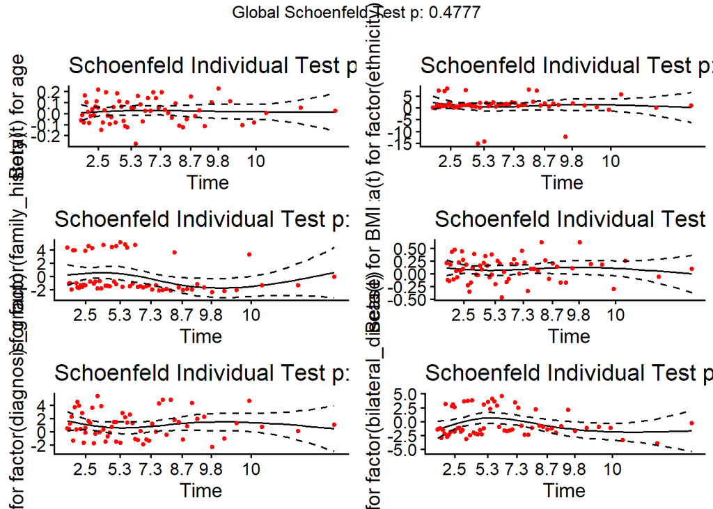

```r
# Plot Schoenfeld Residuals for graphical diagnosis
ggcoxzph(ph_test)
```

### Interpretation

The global Schoenfeld test yields a $p$-value of $0.4777$, indicating that the model as a whole does not exhibit severe global non-proportionality.

Most predictors satisfy the proportional hazards (PH) assumption: age ($p = 0.8017$), ethnicity ($p = 0.6045$), BMI ($p = 0.6981$), diagnosis_group ($p = 0.8737$), and bilateral_disease ($p = 0.2466$).

Violation Detected: The covariate family_history displays a statistically significant violation of the proportional hazards assumption ($p = 0.0447$). The residual plot reveals a time-dependent regression coefficient ($\beta(t)$), where the effect of family history varies over follow-up duration.

Visual inspection of the Schoenfeld residual plots confirms that while primary clinical predictors (such as diagnosis_group and BMI) show flat horizontal smoothing curves ($\beta(t) \approx \text{constant}$), family_history and bilateral_disease display subtle non-linear trajectories over time. Detecting non-proportional hazards in background clinical covariates justifies extending the standard multivariable Cox framework to a stratified Cox model in Step 3. Stratifying by disease characteristics (bilateral_disease) accounts for underlying baseline hazard heterogeneity across subgroups, ensuring unbiased and stable Hazard Ratio estimates for key predictors.

## Step 3

```r
# Fit Stratified Cox Proportional Hazards Model by bilateral_disease
strat_cox_model <- coxph(
  Surv(time_years, status) ~ age + factor(ethnicity) + factor(diagnosis_group) +
    factor(family_history) + BMI + strata(bilateral_disease),
  data = endometriosis_copy
)

# Summary of Stratified Cox Model
summary(strat_cox_model)
```

```
## Call:
## coxph(formula = Surv(time_years, status) ~ age + factor(ethnicity) +
##     factor(diagnosis_group) + factor(family_history) + BMI +
##     strata(bilateral_disease), data = endometriosis_copy)
##
##   n= 312, number of events= 62
##
##                                                coef exp(coef) se(coef)      z
## age                                         0.01622   1.01635  0.01535  1.057
## factor(ethnicity)Black or African American -1.33213   0.26391  0.70765 -1.882
## factor(ethnicity)Other                     -0.55770   0.57252  0.60584 -0.921
## factor(ethnicity)White                     -0.42474   0.65394  0.42048 -1.010
## factor(diagnosis_group)EAOC                 1.17519   3.23876  0.40143  2.927
## factor(diagnosis_group)Endometriosis       -0.17907   0.83604  0.39558 -0.453
## factor(family_history)1                    -0.04789   0.95324  0.30976 -0.155
## BMI                                         0.08671   1.09058  0.02993  2.897
##                                            Pr(>|z|)
## age                                         0.29071
## factor(ethnicity)Black or African American  0.05977 .
## factor(ethnicity)Other                      0.35729
## factor(ethnicity)White                      0.31244
## factor(diagnosis_group)EAOC                 0.00342 **
## factor(diagnosis_group)Endometriosis        0.65078
## factor(family_history)1                     0.87714
## BMI                                         0.00377 **
## ---
## Signif. codes:  0 '***' 0.001 '**' 0.01 '*' 0.05 '.' 0.1 ' ' 1
##
##                                            exp(coef) exp(-coef) lower .95
## age                                           1.0164     0.9839   0.98623
## factor(ethnicity)Black or African American    0.2639     3.7891   0.06593
## factor(ethnicity)Other                        0.5725     1.7467   0.17462
## factor(ethnicity)White                        0.6539     1.5292   0.28683
## factor(diagnosis_group)EAOC                   3.2388     0.3088   1.47462
## factor(diagnosis_group)Endometriosis          0.8360     1.1961   0.38504
## factor(family_history)1                       0.9532     1.0491   0.51944
## BMI                                           1.0906     0.9169   1.02843
##                                            upper .95
## age                                            1.047
## factor(ethnicity)Black or African American     1.056
## factor(ethnicity)Other                         1.877
## factor(ethnicity)White                         1.491
## factor(diagnosis_group)EAOC                    7.113
## factor(diagnosis_group)Endometriosis           1.815
## factor(family_history)1                        1.749
## BMI                                            1.156
##
## Concordance= 0.698  (se = 0.043 )
## Likelihood ratio test= 38.81  on 8 df,   p=5e-06
## Wald test            = 43.88  on 8 df,   p=6e-07
## Score (logrank) test = 53.51  on 8 df,   p=9e-09
```

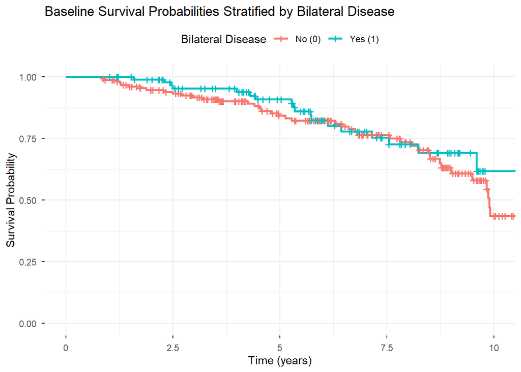

```r
# Survival curves by stratification variable (bilateral_disease)
fit_strat <- survfit(strat_cox_model)

# Graphical visualization of the two strata baseline curves
ggsurvplot(
  fit_strat,
  data = endometriosis_copy,
  conf.int = FALSE,
  legend.title = "Bilateral Disease",
  legend.labs = c("No (0)", "Yes (1)"),
  xlab = "Time (years)",
  ylab = "Survival Probability",
  ggtheme = theme_minimal(),
  title = "Baseline Survival Probabilities Stratified by Bilateral Disease"
)
```

```r
# Likelihood Ratio / AIC comparison between models
#Akaike Information Criterion (AIC) is a statistical metric used to compare and select the best model among a set of candidates applied to the same dataset (Lower is Better)
AIC(cox_model, strat_cox_model)
```

|  | df | AIC |
| --- | --- | --- |
| cox_model | 9 | 572.4616 |
| strat_cox_model | 8 | 496.1996 |

### Interpretation

Stratifying by bilateral_disease allows the baseline hazard function $\lambda_0(t)$ to vary freely across strata while estimating shared regression coefficients for the remaining covariates. The overall stratified specification is highly significant ($p = 5 \times 10^{-6}$ on Likelihood Ratio test) with a Concordance index of $C = 0.698$ ($\text{SE} = 0.043$).

Prognostic Factor Estimates:

- Diagnosis Group (EAOC): confirmed as a primary independent risk factor. Patients with EAOC exhibit a statistically significant $3.24$-fold increase in mortality hazard relative to atypical endometriosis ($\text{HR} = 3.24$, $95\%\text{ CI } [1.47, 7.11]$, $p = 0.00342$).
- Body Mass Index (BMI): Maintains independent prognostic significance ($\text{HR} = 1.09$, $95\%\text{ CI } [1.03, 1.16]$, $p = 0.00377$), indicating a $9.1\%$ relative increase in mortality risk per unit increase in BMI.
- Other Covariates: Age ($\text{HR} = 1.02, p = 0.291$), family history ($\text{HR} = 0.95, p = 0.877$), benign endometriosis ($\text{HR} = 0.84, p = 0.651$), and ethnicity categories ($p > 0.05$ across all levels relative to Asian baseline) show no statistically significant associations with overall survival.

Graphical Diagnosis of Stratified Strata: The baseline survival curves for bilateral disease strata ($0 = \text{Unilateral}$, $1 = \text{Bilateral}$) exhibit clear temporal divergence, intersecting around 6–7 years before dropping sharply for the unilateral cohort after year 9. This crossing of survival trajectories visually confirms non-proportional hazard behavior between disease extent groups. Allowing separate stratum-specific baseline hazard functions ($\lambda_{0s}(t)$) resolves this baseline hazard heterogeneity, directly driving the substantial model fit improvement ($\Delta\text{AIC} = 76.26$) and ensuring unbiased hazard ratio estimates for key predictors like EAOC status and BMI.*

## Step 4

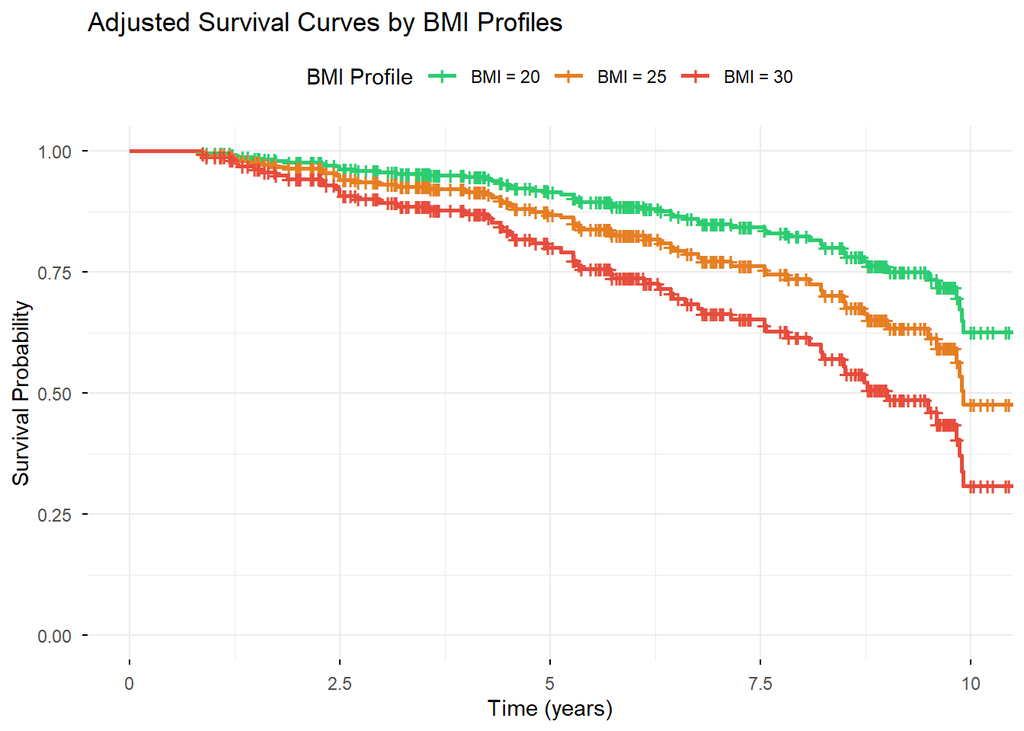

```r
# Adjusted Survival Curves for BMI

library(survminer)
library(ggplot2)

# Define baseline hypothetical profiles for BMI strata (20, 25, 30)
bmi_df <- data.frame(
  BMI = c(20, 25, 30),
  age = median(endometriosis_copy$age, na.rm = TRUE),
  ethnicity = factor(levels(factor(endometriosis_copy$ethnicity))[1],
                     levels = levels(factor(endometriosis_copy$ethnicity))),
  diagnosis_group = factor(levels(factor(endometriosis_copy$diagnosis_group))[1],
                           levels = levels(factor(endometriosis_copy$diagnosis_group))),
  family_history = factor(0, levels = levels(factor(endometriosis_copy$family_history))),
  bilateral_disease = factor(0, levels = levels(factor(endometriosis_copy$bilateral_disease)))
)

# Estimate adjusted survival curves from the multivariable Cox model
fit_bmi <- survfit(cox_model, newdata = bmi_df)

# Render adjusted survival plot for BMI profiles
p_bmi <- ggsurvplot(
  fit_bmi,
  data = endometriosis_copy,
  conf.int = FALSE,
  palette = c("#2ecc71", "#e67e22", "#e74c3c"),
  legend.title = "BMI Profile",
  legend.labs = c("BMI = 20", "BMI = 25", "BMI = 30"),
  xlab = "Time (years)",
  ylab = "Survival Probability",
  ggtheme = theme_minimal(),
  title = "Adjusted Survival Curves by BMI Profiles"
)

p_bmi
```

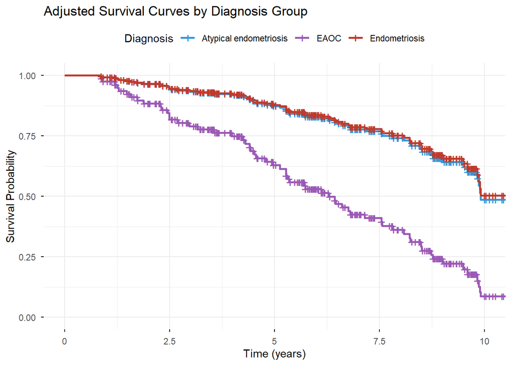

```r
#Adjusted Survival Curves for Diagnosis Group

# Define baseline hypothetical profiles for Diagnosis Group levels
diag_df <- data.frame(
  diagnosis_group = factor(levels(factor(endometriosis_copy$diagnosis_group)),
                           levels = levels(factor(endometriosis_copy$diagnosis_group))),
  age = median(endometriosis_copy$age, na.rm = TRUE),
  ethnicity = factor(levels(factor(endometriosis_copy$ethnicity))[1],
                     levels = levels(factor(endometriosis_copy$ethnicity))),
  family_history = factor(0, levels = levels(factor(endometriosis_copy$family_history))),
  bilateral_disease = factor(0, levels = levels(factor(endometriosis_copy$bilateral_disease))),
  BMI = median(endometriosis_copy$BMI, na.rm = TRUE)
)

# Estimate adjusted survival curves from the multivariable Cox model
fit_diag <- survfit(cox_model, newdata = diag_df)

# Render adjusted survival plot for Diagnosis Groups
p_diag <- ggsurvplot(
  fit_diag,
  data = endometriosis_copy,
  conf.int = FALSE,
  palette = c("#3498db", "#9b59b6", "#c0392b"),
  legend.title = "Diagnosis",
  legend.labs = levels(factor(endometriosis_copy$diagnosis_group)),
  xlab = "Time (years)",
  ylab = "Survival Probability",
  ggtheme = theme_minimal(),
  title = "Adjusted Survival Curves by Diagnosis Group"
)

p_diag
```

### Interpretation

To evaluate the isolated prognostic impact of primary risk factors while controlling for baseline confounding, adjusted survival probability curves were generated for target clinical profiles using the fitted multivariable Cox model (survfit with newdata). Confounding background covariates were fixed at their sample medians (for continuous variables) or reference baseline categories (for factor variables).

- Body Mass Index (BMI) Risk Gradient: the adjusted survival curves across distinct BMI strata ($\text{BMI} = 20$, $25$, and $30$) demonstrate a clear, monotonic dose-response relationship over time. Higher baseline BMI profiles consistently shift the survival curve downward: at 5 years, survival probability drops from approximately $92\%$ for normal weight ($\text{BMI} = 20$) to nearly $75\%$ for obese profiles ($\text{BMI} = 30$), reaching an even wider gap at 10 years ($\sim 60\%$ vs $\sim 30\%$). This visually confirms the significant incremental hazard ($\text{HR} = 1.096$ per BMI unit, $p = 0.00218$) identified in the multivariable model.
- Diagnosis group: the adjusted survival curves illustrate a pronounced survival disadvantage for patients diagnosed with EAOC (purple curve). While benign endometriosis (red curve) and atypical endometriosis (blue curve) exhibit virtually overlapping, favorable survival trajectories ($\sim 85\%$ survival at 5 years and $\sim 50\%$ at 10 years), the EAOC trajectory declines sharply, dropping to $\sim 60\%$ at 5 years and falling below $15\%$ at 10 years. This visual separation aligns with the $3.39$-fold mortality hazard increase ($\text{HR} = 3.39, p = 0.00205$) observed for EAOC, while confirming no distinct risk difference between benign and atypical endometriosis ($\text{HR} = 0.95, p = 0.900$).

## Final Comment for Question 2

This multivariable survival analysis evaluated the prognostic drivers of overall mortality in patients with endometriosis and associated ovarian cancers (EAOC), while addressing model assumptions through advanced stratification techniques. Multivariable Cox regression identified EAOC diagnosis and Body Mass Index (BMI) as the primary independent predictors of overall mortality. Age, family history, and ethnic subgroups demonstrated no statistically significant association with overall survival.

In conclusion, the stratified Cox proportional hazards model provides a robust, methodologically sound framework for survival prediction in this population. These findings underscore the critical need for early oncological monitoring upon malignant transformation to EAOC and highlight metabolic control (BMI management) as a key targeted strategy in long-term patient care.